# IMPACT OF STORMS ON POPULATION HEALTH AND ECONOMY

DMK

6/19/2020

This report briefly examines the cumulative economic and polulation health impact of storms in the US from 1950 - 2007. The report examines data collected from the National Weather Services and utilizes “National Weather Service Instruction 10-1605” published on Aug. 17, 2007. Publication can be found via https://www.nws.noaa.gov/directives –> Operations & Services. Data can be found via https://www.ncdc.noaa.gov/stormevents/ftp.jsp.

```r
knitr::opts_chunk$set(echo = TRUE)

library(dplyr)
```

```r
library(ggplot2)
```

```r
knitr::opts_chunk$set(echo = TRUE)

StormData <- read.csv("./StormData.csv", header = TRUE)
```

Adding columns with actual damage costs using representative letters in “…EXP”

```r
knitr::opts_chunk$set(echo = TRUE)

StormData$CROPCOST <- ifelse(StormData$CROPDMGEXP == "K", as.numeric(StormData$CROPDMG*1000), ifelse(StormData$CROPDMGEXP == "M", as.numeric(StormData$CROPDMG*1000000), ifelse(StormData$CROPDMGEXP == "B", as.numeric(StormData$CROPDMG*1000000000), "0")))

StormData$PROPCOST <- ifelse(StormData$PROPDMGEXP == "K", as.numeric(StormData$PROPDMG*1000), ifelse(StormData$PROPDMGEXP == "M", as.numeric(StormData$PROPDMG*1000000), ifelse(StormData$PROPDMGEXP == "B", as.numeric(StormData$PROPDMG*1000000000), "0")))

## Making sure data are numeric
StormData <- transform(StormData, CROPCOST = as.numeric(CROPCOST), PROPCOST = as.numeric(PROPCOST))
```

Summarize data for easier viewing

```r
knitr::opts_chunk$set(echo = TRUE)

## Summary without State Codes
SDSumm <- StormData %>% group_by(EVTYPE) %>% summarize("TotalCrop" = sum(CROPCOST), "TotalProp" = sum(PROPCOST), "Fatalities" = sum(FATALITIES), "Injuries" = sum(INJURIES))

## Assumption: property & crop damage equal to economic cost, summarized in $ millions
SDSumm$Econ_Millions <- as.numeric((SDSumm$TotalCrop + SDSumm$TotalProp)/1000000)

## Assumption: fatalities and injuries equal to pop. health
SDSumm$PH <- SDSumm$Fatalities + SDSumm$Injuries
```

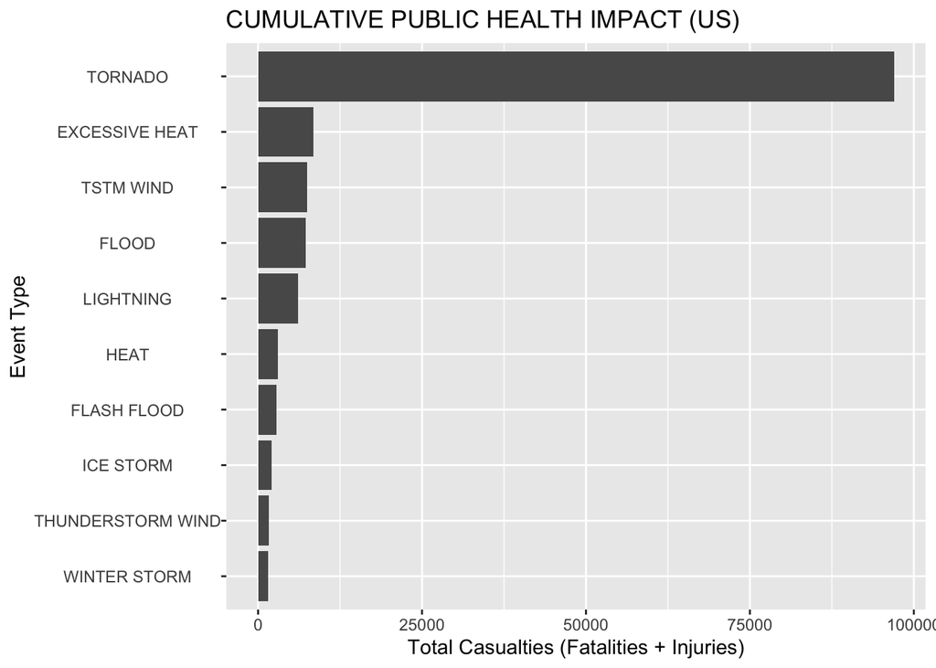

```r
knitr::opts_chunk$set(echo = TRUE)

## Descending sort on public health column
SDSumm <- SDSumm[order(-SDSumm$PH),]

## Chart creation
chart <- ggplot(SDSumm[1:10,], aes(PH, reorder(EVTYPE, PH)))
chart + geom_col() + xlab("Total Casualties (Fatalities + Injuries)") + ylab("Event Type") + ggtitle("CUMULATIVE PUBLIC HEALTH IMPACT (US)") + theme(axis.text.y = element_text(size = 8) + theme(axis.title = element_text(size = 8)))
```

As following chart of top-10 event types (ranked in descending order of cost impact) shows, flooding appears to have the highest economic consequences.

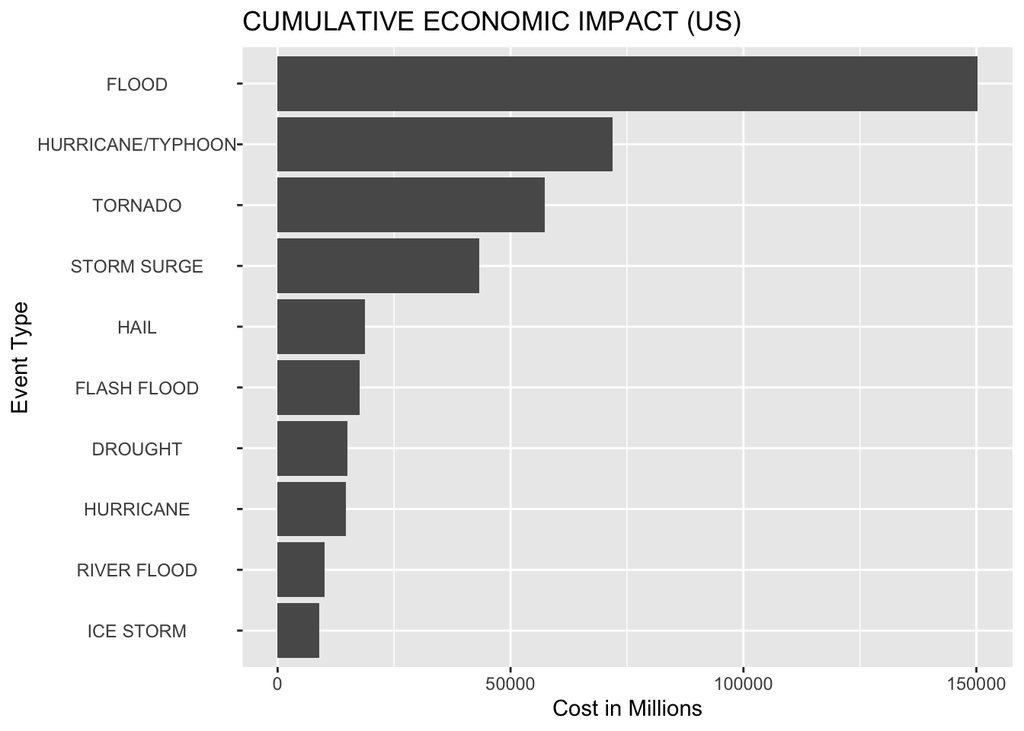

```r
knitr::opts_chunk$set(echo = TRUE)

## Descending sort on public health column
SDSumm <- SDSumm[order(-SDSumm$Econ_Millions),]

## Chart creation
chart2 <- ggplot(SDSumm[1:10,], aes(Econ_Millions, reorder(EVTYPE, Econ_Millions)))
chart2 + geom_col() + xlab("Cost in Millions") + ylab("Event Type") + ggtitle("CUMULATIVE ECONOMIC IMPACT (US)") + theme(axis.text.y = element_text(size = 8) + theme(axis.title = element_text(size = 8)))
```

SUMMARY: Since 1950 (start date of data collection), highest economic costs from weather related events in the US have been due to flooding and highest public health impact (fatalities and injuries) have been due to tornadoes.